# Darren Hunt

11-22-2020

PHYS 434AA

Lab 6

```python
%matplotlib inline
import numpy as np
import matplotlib
import matplotlib.pyplot as plt
import scipy
from scipy import stats
```

# Setting up LHC Background

```python
# generate a fake background, a Poisson with mean=100
bkg = stats.poisson.rvs(mu=100,size=1000000)
```

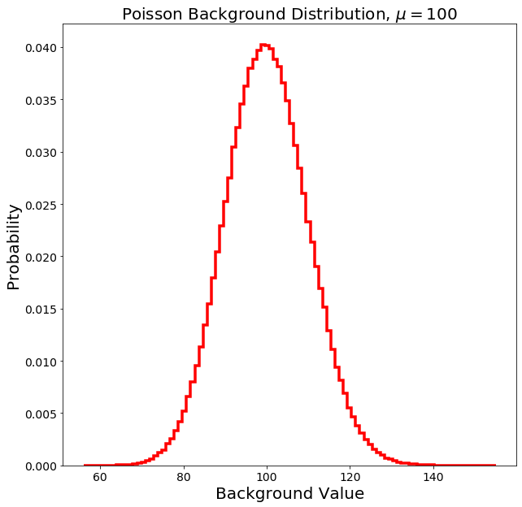

```python
# plot the bkg
fig, ax = plt.subplots(1,1, figsize=(10,10))
plt.style.use('ggplot')

ax.set_title("Poisson Background Distribution, $\mu=100$",fontsize=20)
ax.set_xlabel('Background Value',fontsize=20)
ax.set_ylabel('Probability',fontsize=20)
ax.tick_params(labelsize = 14)

ax.hist(bkg,histtype='step',color='r',density=True,linewidth=3.5,bins=100)

plt.show()
```

To begin, we generate random Poisson-distributed values with a predefined mean of $\mu=100$. This plot allows us to look at the shape of the background distribution before we begin injecting signals. We can see it follows the discrete-valued nature as expected for a Poisson, and is centered at the mean we defined. Setting density to be true allows us to look at the probabilities instead of count frequencies for our background, but either a probability or frequency plot will verify that we created our fake background correctly.

# Finding the $5 \sigma$ Sensitivity Threshold

To find the 5-sigma threshold for our background distribution, we first convert 5 sigma for a Gaussian into its corresponding probability (using cumulative distribution function), then take the inverse with the Poisson's percent point function. This answer will tell us the value 5 standard deviations from the mean which is the cutoff point for a statistically significant observation (above 5 sigma). Anything below this cutoff, we are not guaranteed it is not just part of the background.

```python
# calculate 5sigma threshold
p = stats.norm.cdf(5)
thresh = stats.poisson.ppf(p,mu=100)
print("Sensitivity threshold for background = "+str(thresh))
```

```
Sensitivity threshold for background = 154.0
```

The cutoff value is 154. Any number of events lower than this is not statisticially significant and may be part of the background distribution.

# Injecting a Known Signal

First, we need to come up with a strong signal between 8-30$\sigma$. To do this, we follow the steps from the previous question. After determining a set signal strength to use, we can inject this many times by randomly generating a Poisson-shaped distribution using this mean repeatedly.

```python
sig16 = stats.norm.cdf(8)  # using sigma = 16
strength = stats.poisson.ppf(sig16,mu=100)
print("Signal strength for sigma = 16 : "+str(strength))
```

[output not shown]

So, signal strengths higher than 190 will work.

Using a signal strength of 215, we can now generate a Poisson-shaped distribution about that mean.

```python
sigmu = 215
signal = stats.poisson.rvs(sigmu,size=200000)
```

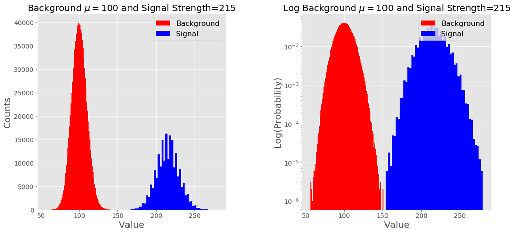

```python
# now plot with the background histogram.
fig, (ax1,ax2) = plt.subplots(1,2, figsize=(18,8),gridspec_kw={'wspace': 0.4})
plt.style.use('ggplot')

ax1.set_title("Background $\mu=100$ and Signal Strength=215",fontsize=20)
ax2.set_title("Log Background $\mu=100$ and Signal Strength=215",fontsize=20)
ax1.set_xlabel('Value',fontsize=20), ax2.set_xlabel('Value',fontsize=20)
ax1.set_ylabel('Counts',fontsize=20), ax2.set_ylabel('Log(Probability)',fontsize=20)
ax1.tick_params(labelsize=14), ax2.tick_params(labelsize=14)

ax1.hist(bkg,color='r',bins=100,label='Background'), ax1.hist(signal,color='b',bins=50,label='Signal')
ax2.hist(bkg,color='r',density=True,bins=100,label='Background'), ax2.hist(signal,color='b',density=True,bins=50,label='Signal')
ax2.set_yscale('log')

ax1.legend(loc='best',fontsize=16)
ax2.legend(loc='upper right',fontsize=16)
plt.show()
```

Here, the same background distribution with a mean of 100, and the new random signal based on a strength of 215 are plotted side by side. Once signal injection happens, when we add the signal directly to the background, the mean values will shift. The raw signal shares no values with the background distribution; this is due to the much higher strength we deliberately chose. Almost all values of the background will fall within the 5-sigma range, so we can expect these two to have no overlap before injection. The log plot allows us to confirm both the background and signal appear Gaussian shaped.

```python
# add signal to the background
# first reshape the signal to be the same size as bkg
l = len(bkg) - len(signal)
s = np.append(signal, values=np.zeros(l))
inject = bkg + s
```

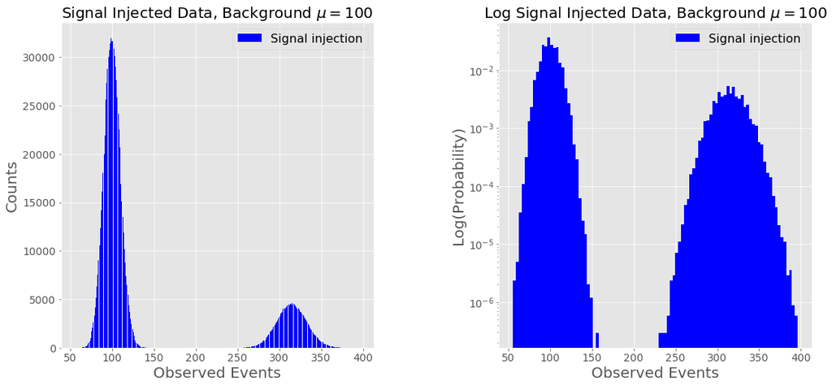

```python
# now plot the data resulting from the signal injection
fig, (ax1,ax2) = plt.subplots(1,2, figsize=(18,8),gridspec_kw={'wspace': 0.4})
plt.style.use('ggplot')

ax1.set_title("Signal Injected Data, Background $\mu=100$",fontsize=20)
ax2.set_title("Log Signal Injected Data, Background $\mu=100$",fontsize=20)
ax1.set_xlabel('Observed Events',fontsize=20), ax2.set_xlabel('Observed Events',fontsize=20)
ax1.set_ylabel('Counts',fontsize=20), ax2.set_ylabel('Log(Probability)',fontsize=20)
ax1.tick_params(labelsize=14), ax2.tick_params(labelsize=14)

ax1.hist(inject,color='b',bins=400,label='Signal injection')
ax2.hist(inject,color='b',density=True,bins=100,label='Signal injection')
ax2.set_yscale('log')

ax1.legend(loc='best',fontsize=16)
ax2.legend(loc='upper right',fontsize=16)
plt.show()
```

These histograms show us the background and the observed data distributions post-signal injection. The log plot shows more clearly the true distribution shapes and the minor changes along the curves; as we can see, both the background and the observation shapes appear parabolic on the log plot and therefore approached a Gaussian distribution.

After signal injection into the background, there are two notable changes to the histogram distributions: One, the peaks have changed. Both curves have shorter peaks (in counts) than pre-signal injection. Second, most importantly, the observed signal has changed. While the background remains the same as expected, since our fake background doesn't change with time or any other expected changes, the signal histogram shape has now shifted up on the x-axis. Looking closer, we see the peak, where the mean is located, has shifted up exactly by 100, from 215 to 315.

This upwards shift along the x-axis happens due to the additive nature of the background. The background mean is 100, therefore all values within the signal distribution have 100 added.

What we are looking at then is the background and the signal together. The true signal is not actually this much stronger. Instead, the background is just adding to the value we observe or measure. To get the true signal, we would have to subtract the background out in a real experiment.

# Injecting a Random, Uniform Range of Signals

Instead of injecting a signal Poisson-distributed about a single mean, this time we can randomly generate a large amount of signals in a given range. We can start at 0, and going several sigmas above the 5-sigma threshold of 154 events, we can stop a few hundred events greater, say 400. In order to avoid an implicit prior, we need to ensure the random values are uniformly distributed, and have equal probabilities of strength at either end of the signal range.

```python
# generate a uniform signal suite
signalrange = np.random.uniform(low=0,high=400,size=1000000)
# inject signal to the original background
data = bkg + signalrange
```

```python
signaledges = np.linspace(0,400,800)
dataedges = np.linspace(-7,500,100)

Psd, temp, temp2= np.histogram2d(data,signalrange, bins=[dataedges,signaledges], density=True)
datacenters = (dataedges[:-1] + dataedges[1:]) / 2
signalcenters = (signaledges[:-1] + signaledges[1:]) / 2

tsig = [215]*(len(dataedges)-2)
```

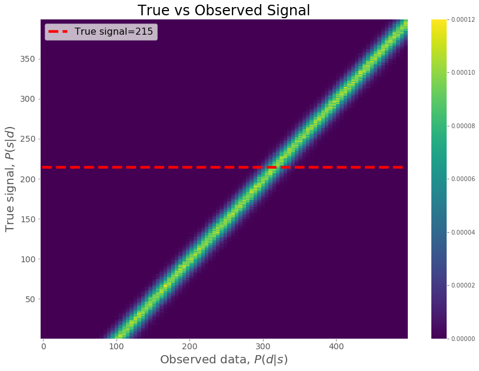

```python
fig, ax = plt.subplots(1,1, figsize=(14,10))
ax.set_title("True vs Observed Signal",fontsize=24)
ax.set_xlabel('Observed data, $P(d|s)$',fontsize=20)
ax.set_ylabel('True signal, $P(s|d)$',fontsize=20)
plt.tick_params(labelsize = 14)
plt.pcolormesh(datacenters,signalcenters,Psd.T)

plt.plot(dataedges[1:-1],tsig,linestyle='--',linewidth=4.5,color='r',label='True signal=215')
plt.colorbar()

ax.legend(loc='upper left', fontsize=16)
plt.show()
```

This 2D histogram shows the spread of possible values of the true signal given an observed value that we actually measure. It can also be looked at in reverse, telling us the possible observed data values given a true injected signal. There is spread, or uncertainty, in both directions. If we know one with certainty (say an observed value from a lab measurement) we won't exactly know what the true signal is. This is due to the nature of the background addition. The spread in the possible background values added mean there will be a similar spread of added values to whatever signal we observe. Therefore, this is simulating the uncertainty in the possible different true signals if the background adds varying values from its distribution to the true signal value.

We can also check our previous results using this histogram. Previously, the signal strength was 215 (horizontal line on the plot). We can slice the data from that horizontal line and plot a histogram to look at the distribution of the observed data values possible.

```python
obsvals = []
for i in range(len(data)):
    if signalrange[i] >= 215.0 and signalrange[i] <= 215.90:
        obsvals.append(data[i])
```

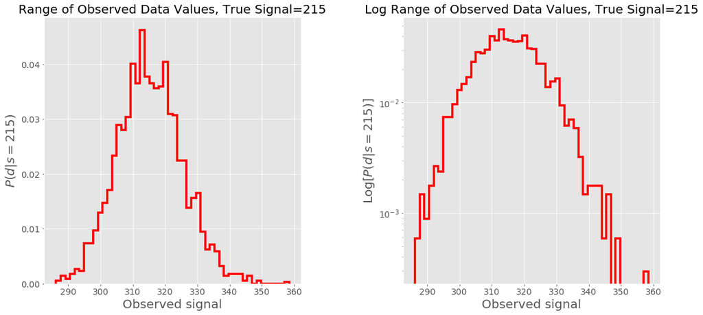

```python
# plot the range of possible observed data values for this true signal
fig, (ax1,ax2) = plt.subplots(1,2, figsize=(18,8),gridspec_kw={'wspace': 0.4})
plt.style.use('ggplot')

ax1.set_title("Range of Observed Data Values, True Signal=215",fontsize=20)
ax2.set_title("Log Range of Observed Data Values, True Signal=215",fontsize=20)
ax1.set_xlabel('Observed signal',fontsize=20), ax2.set_xlabel('Observed signal',fontsize=20)
ax1.set_ylabel('$P(d|s=215)$',fontsize=20), ax2.set_ylabel('Log[$P(d|s=215)$]',fontsize=20)
ax1.tick_params(labelsize = 14), ax2.tick_params(labelsize = 14)

ax1.hist(obsvals,histtype='step',color='r',density=True,linewidth=3.5,bins=50)
ax2.hist(obsvals,histtype='step',color='r',density=True,linewidth=3.5,bins=50)
ax2.set_yscale('log')

plt.show()
```

```python
mu = np.mean(obsvals)
print("Mean : " + str("{0:.2f}".format(mu)))
```

```
Mean : 315.34
```

Using a different method, this mean is exactly what what we determined earlier. Where the signal strength was given to be 215, and the additive background mean was exactly 100, we expected 315 as the first outcome. This recalculation yields the same expected mean. We see the background addition onto the signal and therefore get a range of possible observed values due to this background.

Now we can invert the problem. Instead of taking a known true signal and finding the observed value range, we will take and observed signal and find the spread in possible true signal values. The 2D histogram below shows the line where we slice the data from and plot a histogram of spread. I arbitrarily chose an observed signal value of 353.

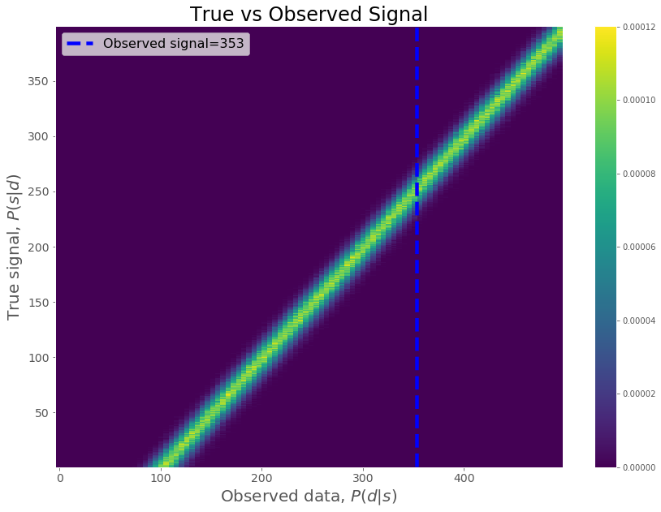

```python
d = [353]*(len(signaledges)-2)

fig, ax = plt.subplots(1,1, figsize=(14,10))
ax.set_title("True vs Observed Signal",fontsize=24)
ax.set_xlabel('Observed data, $P(d|s)$',fontsize=20)
ax.set_ylabel('True signal, $P(s|d)$',fontsize=20)
plt.tick_params(labelsize = 14)
plt.pcolormesh(datacenters,signalcenters,Psd.T)

plt.plot(d,signaledges[1:-1],linestyle='--',linewidth=4.5,color='b',label='Observed signal=353')
plt.colorbar()

ax.legend(loc='upper left', fontsize=16)
plt.show()
```

```python
tsigvals = []
for i in range(len(data)):  # obs = 11.3
    if data[i] >= 353.0 and data[i] <= 353.90:
        tsigvals.append(signalrange[i])
```

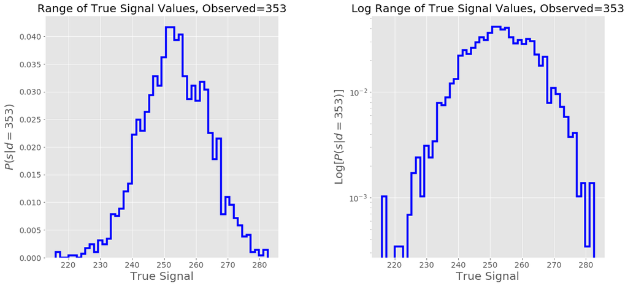

```python
# plot the range of possible true signal values for observed=353
fig, (ax1,ax2) = plt.subplots(1,2, figsize=(18,8),gridspec_kw={'wspace': 0.4})
plt.style.use('ggplot')

ax1.set_title("Range of True Signal Values, Observed=353",fontsize=20)
ax2.set_title("Log Range of True Signal Values, Observed=353",fontsize=20)
ax1.set_xlabel('True Signal',fontsize=20), ax2.set_xlabel('True Signal',fontsize=20)
ax1.set_ylabel('$P(s|d=353)$',fontsize=20), ax2.set_ylabel('Log[$P(s|d=353)$]',fontsize=20)
ax1.tick_params(labelsize = 14), ax2.tick_params(labelsize = 14)

ax1.hist(tsigvals,histtype='step',color='b',density=True,linewidth=3.5,bins=50)
ax2.hist(tsigvals,histtype='step',color='b',density=True,linewidth=3.5,bins=50)
ax2.set_yscale('log')

plt.show()
```

```python
tmean = np.mean(tsigvals)
print("Mean : " + str("{0:.2f}".format(tmean)))
```

```
Mean : 253.42
```

These histograms now show us the possible true signal values if we observe a value of 353. The true signal holds its Gaussian shape according to the log plot. Looking along the x-axis, we can see that the true signal values possible are 100 less than the observed. This is because the background is subtracted out for a true signal, and as before, the background mean is 100. Therefore, a true signal significantly lower than the observed signal is what we expect.

There is still a range of possible values for the inverted problem. Though we have measured a value of 353, the signal still has a spread. Again, this is due to uncertainty from the background. The background may add a little more or less than the mean. We still expect the mean to be most probable, but the true signal could fall on either side of this mean according to the background.

Since there is this spread in the possible true signal values, we can calculate the 1$\sigma$ uncertainty. The 1$\sigma$ uncertainty tells us that 67% of the time, the true signal will fall within one sigma from the mean on either side.

```python
# calculate 1 sigma uncertainty
# calculate each side separately to ensure it's symmetric
onesig = stats.norm.cdf(1)
onesigneg = stats.norm.cdf(-1)
upper = stats.poisson.ppf(onesig,mu=tmean)
lower = stats.poisson.ppf(onesigneg,mu=tmean)

plus = upper - tmean
minus = tmean - lower

print("1-sigma uncertainty, upper : "+str("{0:.2f}".format(plus))+", Upper bound : "+str(upper))
print("1-sigma uncertainty, lower : "+str("{0:.2f}".format(minus))+", Lower Bound : "+str(lower))
```

```
1-sigma uncertainty, upper : 15.58, Upper bound : 269.0
1-sigma uncertainty, lower : 15.42, Lower Bound : 238.0
```

Therefore, we can expect a true signal of the mean, plus or minus these bounds, within the 1-sigma uncertainty confidence interval. We are pretty confident the true signal falls somewhere within that range.

I calculated both the upper and lower bounds separately to check if it truly is symmetric. The above calculations show that it is symmetric about the mean. We can expect the values to evenly fall within 1 sigma of either side, a value of plus or minus 15 events. The symmetry shows that you are equally likely to fall left of the mean as you are to fall to the right. Therefore, we can most likely expect the mean, or another value within + or - 15 of the mean.

This makes sense. Our data is randomly generated each time this code is rerun, but it is expected to follow a Poisson distribution regardless. With many samples, we see the shape approaching to a Gaussian distribution, symmetric about whichever mean we input. In this lab, we used a mean of 100 for the background. Throughout the lab, I only saw minor fluctuations from the expected shape, but it never deviated from an approximately symmetric shape. Additionally, we made sure to randomly generate the signal as uniform to avoid weighting either side too heavily. If we had not generated this uniformly, we would likely see some asymmetry or more bias. The uniform range of signals is an attempt to eliminate the bias that we saw in the previous problem.